# Reporte de Prácticas 1

Ramos Galguera Johana Itzel, Marín Peralta Alejandro Efraín, Talavera Cruz María Fernanda

2023-04-20

# 1 Abstract

# 2 Introduction

# 3 Methods

First of all, a new directory in the DNA High-Performance Computing Cluster was created, which is

```bash
/mnt/Timina/bioinfoII/amarin/RNAseq2/
```

This directory has the next organization:

```bash
|-data/           # Directory to download the raw data
|-data_trimmed/   # Directory to save the post-QC data
|-kallisto_out/   # Directory to save the kallisto outputs
|-QC/             # Directory to perform raw QC
|-QC_trimmed/     # Directory to perform QC on the trimmed data
|-scripts/        # Some scripts used to send jobs
```

## 3.1 Download

The dataset choose to analysis has de GEO Accession GSE91061. Since downloading from the NCBI may be difficult and quite technical, it was choosen to use the European mirror, the [European Nucleotide Archive](https://www.ebi.ac.uk/ena/browser/home) from the EMBL-EBI. By browing on the GEO web page, we see that the data are from the BioProject PRJNA356761. We use that ID to search on ENA.

[figure not shown]

Due the fact that the are a lot of file needed to be downloaded, we use the web application [SRA Explorer](https://sra-explorer.info/) to get a script to get the bulk download.

[figure not shown]

We then select all the files and click on “Add to collection”. After that, we see our saves datasets and select the bash script for downloading FastQ files option. We save the script with the name `downloadScript.sh`, and save it in the HPCC, in the `//data/` directory.

Then, we send a job using the script. It lasted around 5 days.

## 3.2 Raw Quality Control

Once the data is ready, we perform quality control. We just send a job using fastqc with all the `fastq` files via a wildcard:

```bash
fastqc /mnt/Timina/bioinfoII/amarin/RNAseq2/data/*fastq.gz -o /mnt/Timina/bioinfoII/amarin/RNAseq2/QC
```

Then, we used multiqc to visualize all the samples at once:

```bash
multiqc /mnt/Timina/bioinfoII/amarin/RNAseq2/QC -o /mnt/Timina/bioinfoII/amarin/RNAseq2/QC
```

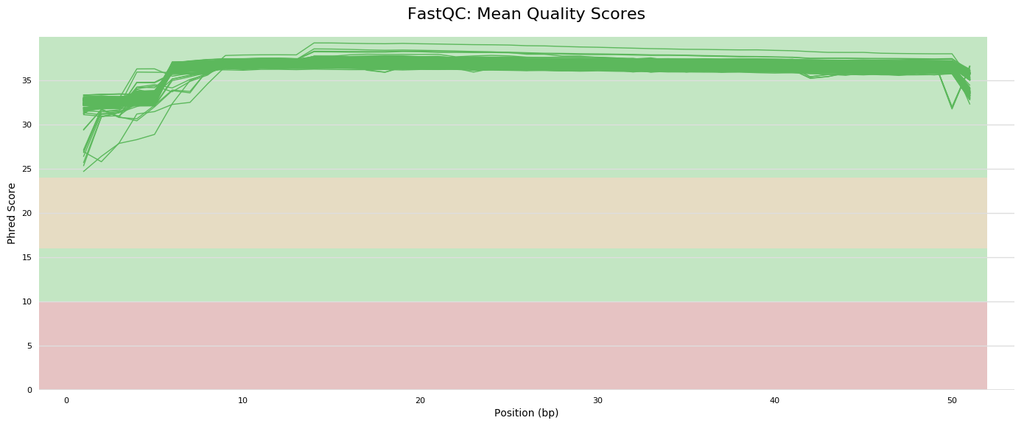

Besides, in the heatmap, the base sequence sequence content seemed to be biased on the first base pairs of the read.

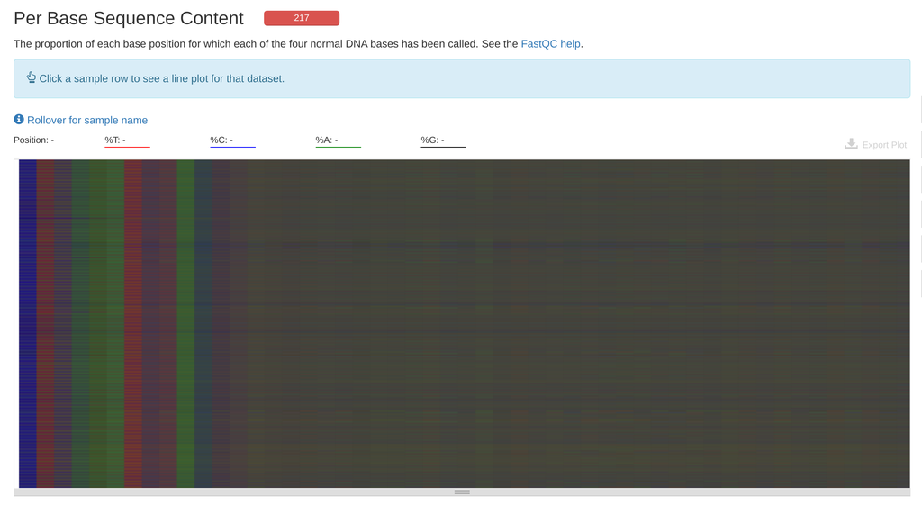

All the samples resembled more or less the next percentage of base content.

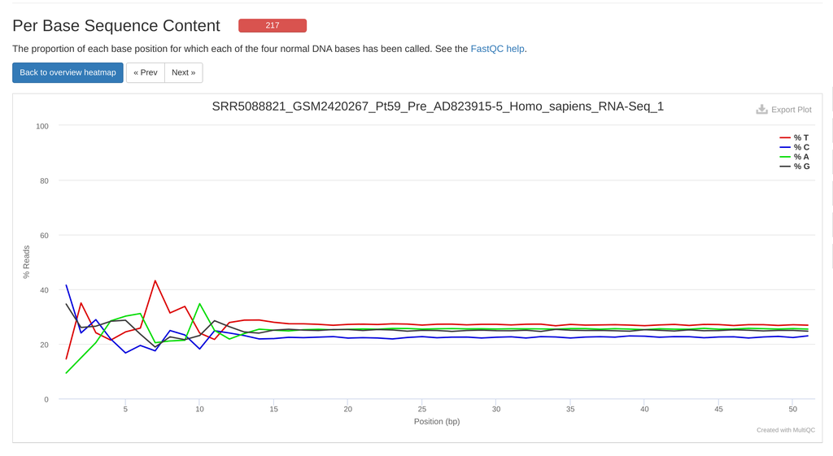

Nevertheless, MultiQC didn’t detect any adapter content. Based on that, we decided to trimm the first 12 nucleotides of each pair.

## 3.3 Trimming

We send a job in the `//data/` directory with a script using the software Trimmomatic:

```bash
for i in *_1.fastq.gz;
    do echo
    trimmomatic PE -threads 40 -phred33 -trimlog trim.log \
        $i "${i%_1.fastq.gz}_2.fastq.gz" \
        ../data_trimmed/"${i%_1.fastq.gz}_1_trimmed.fastq.gz" \
        ../data_trimmed/"${i%_1.fastq.gz}_1_unpaired.fastq.gz" \
        ../data_trimmed/"${i%_1.fastq.gz}_2_trimmed.fastq.gz" \
        ../data_trimmed/"${i%_1.fastq.gz}_2_unpaired.fastq.gz" \
        HEADCROP:12
  done
```

Here we just cut the first 12 nucleotides of each read and create a `trim.log` log file by the use of 40 threads. We know that the Phred score are based on ASCII 33 because previously we found a `#` symbol on the reads.

This job took a couple of days.

## 3.4 Trimmed Quality Control

Once the data was trimmed, we did one more time the quality control.

```bash
fastqc /mnt/Timina/bioinfoII/amarin/RNAseq2/data_trimmed/*fastq.gz \
  -o /mnt/Timina/bioinfoII/amarin/RNAseq2/QC_trimmed
multiqc /mnt/Timina/bioinfoII/amarin/RNAseq2/QC_trimmed \
  -o /mnt/Timina/bioinfoII/amarin/RNAseq2/QC_trimmed
```

This time, the quality of the first pair bases was better.

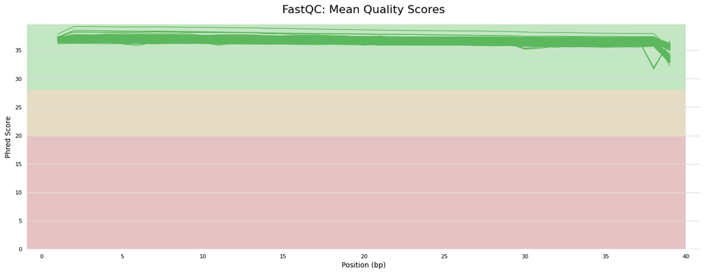

Besides, the “per base sequence content” was less biased:

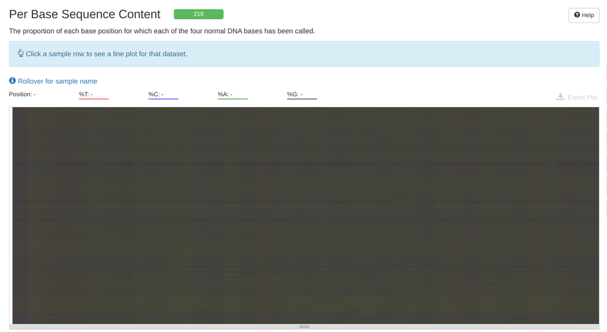

Each sample was more homogeneous.

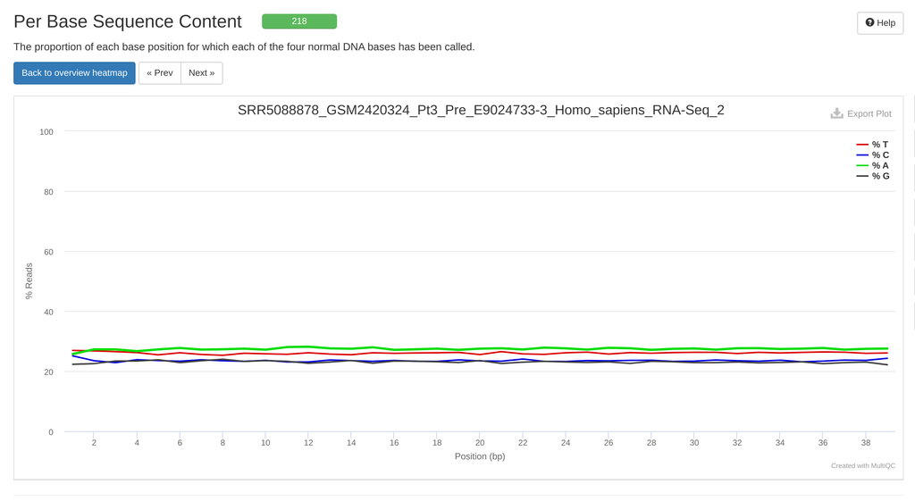

Besides, other indicators, such as the “per base N content” and “per sequence GC content” performed better.

## 3.5 Pseudoaligment to reference genome

Once the data was ready, we decided to generate count matrices using Kallisto. To perform this, we first need a reference transcriptome. We choose the latest version available at [GENCODE](https://www.gencodegenes.org/human/), which is the release 43. The file was downloaded at the parent directory of this project:

```bash
wget https://ftp.ebi.ac.uk/pub/databases/gencode/Gencode_human/release_43/gencode.v43.transcripts.fa.gz
```

Then, generated the kallisto index:

```bash
kallisto index -i /mnt/Timina/bioinfoII/amarin/RNAseq2/kallisto_out/Hs_ref.kidx \
  /mnt/Timina/bioinfoII/amarin/RNAseq2/gencode.v43.transcripts.fa.gz
```

Then, we used a bash script to perform the quantification with all the samples.

```bash
for file in /mnt/Timina/bioinfoII/amarin/RNAseq2/data_trimmed/*_1_trimmed.fastq.gz
do
    op=$(basename $file | cut -c-10 )
    file2=$(echo $file | sed 's/_1_/_2_/')
    mkdir /mnt/Timina/bioinfoII/amarin/RNAseq2/kallisto_out/${op}

    kallisto quant -i /mnt/Timina/bioinfoII/amarin/RNAseq2/kallisto_out/Hs_ref.kidx \
    -o /mnt/Timina/bioinfoII/amarin/RNAseq2/kallisto_out/${op} \
    --threads 40 $file $file2
done
```

## 3.6 Differencial Expresion

### 3.6.1 Data importation

### 3.6.2 Exploratory Analysis

### 3.6.3 Differencial Expresion Analysis

## 3.7 Gene Ontology Enrichment

# 4 Results

# 5 Conclusions

# 6 References